# Practical - advanced

Aurelien Ginolhac, Eric Koncina

3<sup>rd</sup> June 2016

> This practical work is adapted from the exhaustive example published by David Robinson on [his blog](http://varianceexplained.org/r/tidy-genomics/).

In [2008, Brauer et al.](http://www.molbiolcell.org/content/19/1/352.abstract) used microarrays to test the effect of starvation on the growth rate of yeast. For example, they tried limiting the yeast’s supply of glucose (sugar to metabolize into energy), of leucine (an essential amino acid), or of ammonium (a source of nitrogen).

## Project - set-up

- Create a new project in a meaningful folder name (such as `R_workshop/day2-advanced`) on your computer using the project manager utility in the upper-right part of the rstudio window.
- Create a folder `data`
- Download [`Brauer2008_DataSet1.tds`](https://lsru.github.io/r_workshop/data/Brauer2008_DataSet1.tds) inside the `data` folder

Load the [`Brauer2008_DataSet1.tds`] file into a dataframe. This is the exact data that was published with the paper (though for some reason the link on the journal’s page is broken). It thus serves as a good example of tidying a biological dataset “found in the wild”.

```r
original_data <- read_tsv("data/Brauer2008_DataSet1.tds")
```

# 1 Tidying the data

Have a look at the dataset. Is the data “tidy”?

## 1.1 Many variables are stored in one column

```r
cat(as.character(original_data$NAME[1:3]), sep = "\n")
```

```
## SFB2       || ER to Golgi transport || molecular function unknown || YNL049C || 1082129
## || biological process unknown || molecular function unknown || YNL095C || 1086222
## QRI7       || proteolysis and peptidolysis || metalloendopeptidase activity || YDL104C || 1085955
```

- **Gene name** e.g. *SFB2*. Note that not all genes have a name.
- **Biological process** e.g. “proteolysis and peptidolysis”
- **Molecular function** e.g. “metalloendopeptidase activity”
- **Systematic ID** e.g. *YNL049C*. Unlike a gene name, every gene in this dataset has a systematic ID.
- **Another ID number** e.g. `1082129`. I don’t know what this number means, and it’s not annotated in the paper. Oh, well.
1. Use the appropriate function provided in the `tidyr` library to split these values and generate a column for each variable.

## Solution

```r
cleaned_data <- original_data %>%
  separate(NAME, c("name", "BP", "MF", "systematic_name", "number"), sep = "\\|\\|")
```

2. Once you separated the variables delimited by two “`||`”, check closer the new values: You will see that they might start and/or end with whitespaces which might be inconvinient during the subsequent use.
   - To remove these whitespaces, R base provides a function called `trimws()`. Let’s test how the function works:
   - Dplyr allows us to apply a function (in our case `trimws()`) to all columns. In other words, we would like to modify the content of each column with the output of the function `trimws()`. How can you achieve this? Save the result in a data frame called `cleaned_data`.

```r
# Creating test string with whitespaces:
s <- "  Removing whitespaces at both ends "
s
```

```
## [1] "  Removing whitespaces at both ends "
```

```r
trimws(s)
```

```
## [1] "Removing whitespaces at both ends"
```

## Solution

```r
cleaned_data <- original_data %>%
  separate(NAME, c("name", "BP", "MF", "systematic_name", "number"), sep = "\\|\\|") %>%
  mutate_each(funs(trimws), name:systematic_name)
```

3. We are not going to use every column of the dataframe. Remove the unnecessary columns: `number`, `GID`, `YORF` and `GWEIGHT`.

## Solution

```r
cleaned_data %>%
  select(-number, -GID, -YORF, -GWEIGHT) -> cleaned_data
```

Look at the column names.  
Do you think that our dataset is now “tidy”?

## Solution

No, our dataframe is still not tidy. We can see that the column names from G0.05 to U0.3 represent a variable.

## 1.2 Column headers are values, not variable names

- Keep care to build a dataframe with each column representing a variable: At this point we are storing the sample name as a different column `sample` associated to values in `expression` column. Save as `cleaned_data_melt`

## Solution

```r
cleaned_data %>%
  gather(sample, expression, G0.05:U0.3) -> cleaned_data_melt
```

Now look at the content of the `sample` column. We are again facing the problem that two variables are stored in a single column.

## Solution

```r
levels(cleaned_data_melt$sample)
```

Use the same function as before to split the `sample` column into two variables `nutrient` and `rate` (use the appropriate delimitation in `sep` and consider using the `convert` argument).

## Solution

```r
cleaned_data_melt %>%
  separate(sample, c("nutrient", "rate"), sep = 1, convert = TRUE) -> cleaned_data_melt
```

# 2 Representing the data

Tidying the data is a crucial step allowing easy handling and representing.

## 2.1 Plot the expression data of the LEU1 gene

Extract the data corresponding to the gene called “LEU1” and draw a line for each nutrient showing the expression in function of the growth rate.

## Solution

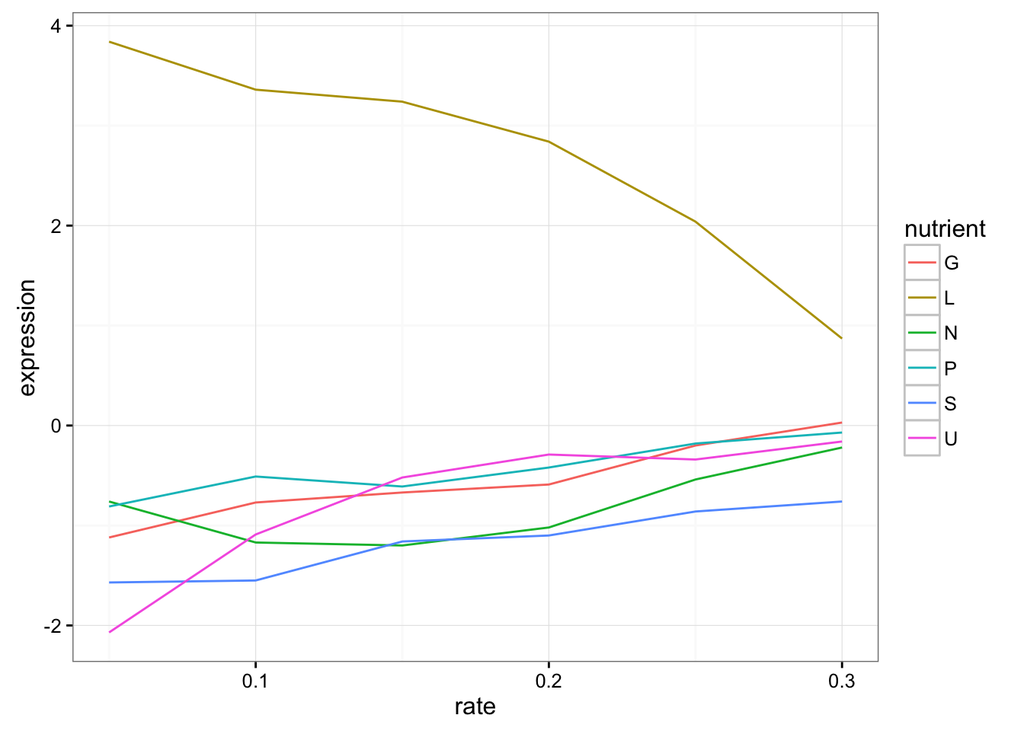

```r
cleaned_data_melt %>%
  filter(name == "LEU1") %>%
  ggplot(aes(rate, expression, colour = nutrient)) +
  geom_line() +
  theme_bw()
```

## 2.2 Plot the expression data of a biological process

For this, we don’t need to filter by single gene names as the raw data provides us some information on the biological process for each gene.  
Extract all the genes in the “leucine biosynthesis” process and plot the expression in function of the growth rate for each nutrient.

## Solution

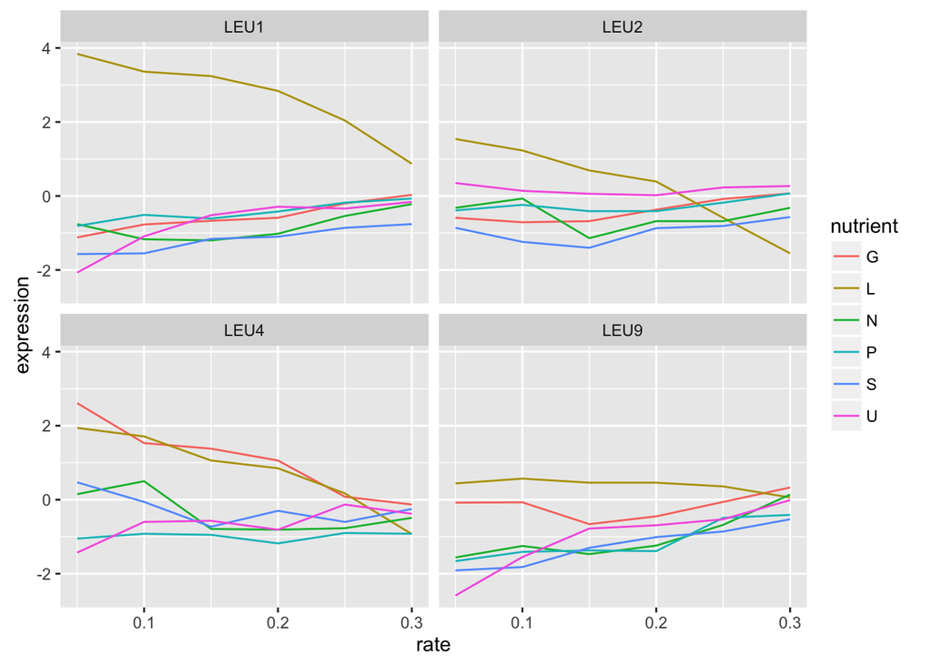

```r
cleaned_data_melt %>%
  filter(BP == "leucine biosynthesis") %>%
  ggplot(aes(rate, expression, color = nutrient)) +
  geom_line() +
  facet_wrap(~ name)
```

## 2.3 Perform a linear regression in top of the plots

Let’s play with the graph a little more. These trends look vaguely linear.  
Add a linear regression with the appropriate `ggplot2` function and carrefully adjust the `method` argument.

## Solution

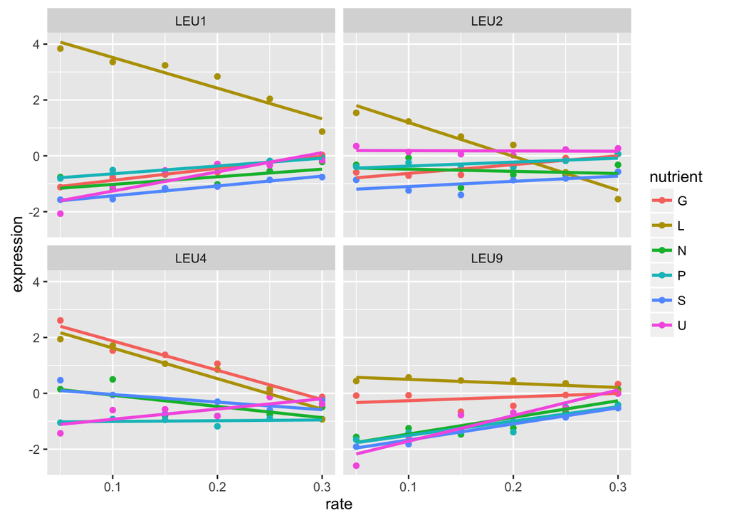

```r
cleaned_data_melt %>%
  filter(BP == "leucine biosynthesis") %>%
  ggplot(aes(rate, expression, colour = nutrient)) +
  geom_point() +
  geom_smooth(method = "lm", se = FALSE) +
  facet_wrap(~ name)
```

## 2.4 Switch to another biological process

Once the dataset is tidy, it is very easy to switch to another biological process. Instead of the “leucine biosynthesis”, plot the data corresponding to “sulfur metabolism”.

## Solution

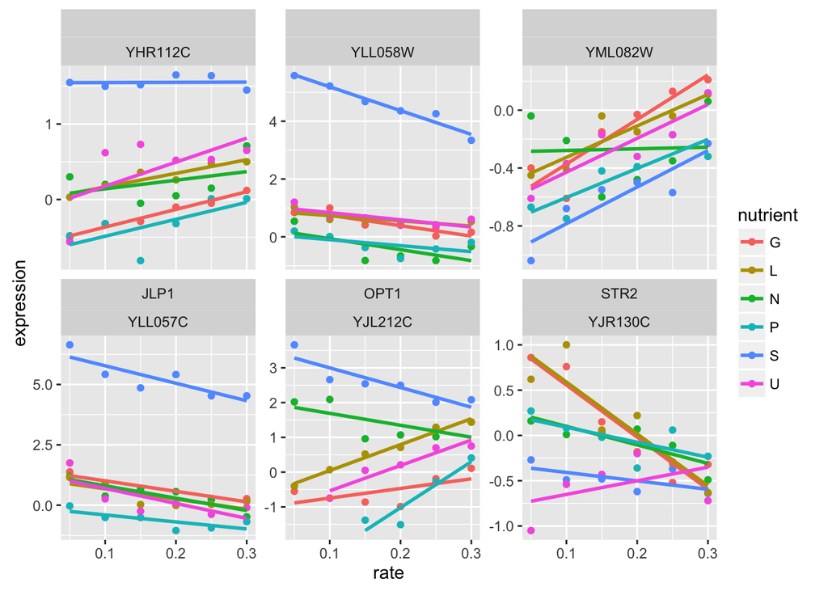

```r
cleaned_data_melt %>%
  filter(BP == "sulfur metabolism") %>%
  ggplot(aes(x = rate, y = expression, colour = nutrient)) +
  geom_point() +
  geom_smooth(method = "lm", se = FALSE) +
  facet_wrap(~ name + systematic_name, scales = "free_y") # add 2 headers to facets with '+'
```

# 3. Linear models

*We are following the `gapminder` example written by Hadley.*

## 3.1 Nest data for systematic_name and nutrient

Before applying a linear regression to all genes, we must further clean the data. A linear model will be build with at least 6 rate points. Filter out the genes that have less than 6 data points. Moreover, some systematic_name and expression data are missing (`NA`). Filter them out too.

Then, nest the data and save the result as `cleaned_nest`.

## Solution

```r
cleaned_data_melt %>%
  filter(!is.na(expression),!is.na(systematic_name)) %>%
  group_by(nutrient, systematic_name) %>%
  mutate(n = n()) %>%
  filter(n > 5) %>%
  nest() -> cleaned_nest
```

## 3.2 Perform all linear models

Mutate the `cleaned_nest` data frame and, for all genes / nutrient, perform a linear regression of `expression` explained by `rate`.

## Warning

The computation takes ~ 40 sec on my macbook pro. Save as `cleaned_lm`.

## Solution

```r
library("purrr")
```

```r
cleaned_nest %>%
  mutate(model = map(data, function(x) lm(expression ~ rate, data = x))) -> cleaned_lm
```

- How many models did you perform?

## Solution

the nrow of cleaned_nest is 32543 models

## 3.3 Tidy the linear models

Similarly as the life expectancy, use the 3 main functions of `broom` to - `glance` the models - extract the $r^2$ - `tidy` models - `augment` to extract residuals

```r
cleaned_lm %>%
  sample_frac(0.05) %>%
  mutate(...)
```

```r
library("broom")
cleaned_lm %>%
  mutate(glance  = map(model, glance),
         rsq     = glance %>% map_dbl("r.squared"),
         tidy    = map(model, tidy),
         augment = map(model, augment)) -> cleaned_lm
```

## 3.4 Explore models

- plot the histogram of $r^2$ for each nutrient. What can you say?

## Solution

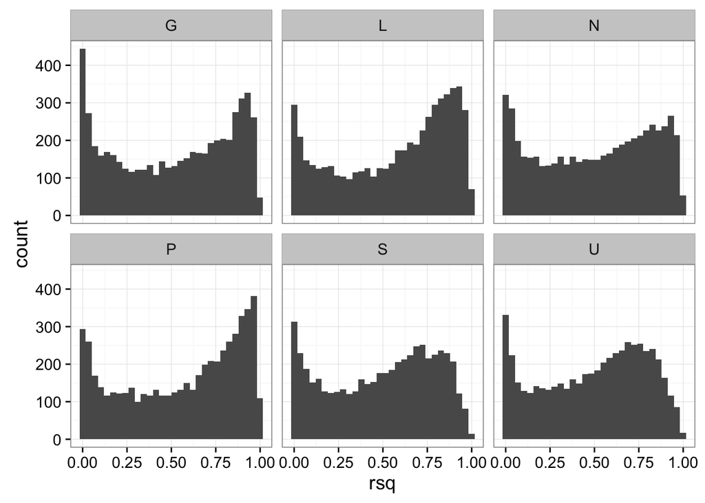

```r
theme_set(theme_bw(14))
cleaned_lm %>%
  ggplot(aes(x = rsq))+
  geom_histogram()+
  facet_wrap(~ nutrient)
```

## Solution

- Count how many models have a $r^2 > 0.9$ per nutrient

## Solution

```r
cleaned_lm %>%
  filter(rsq > 0.9) %>%
  count(nutrient)
```

```
## Source: local data frame [6 x 2]
##
##   nutrient     n
##      (chr) (int)
## 1        G   756
## 2        L   815
## 3        N   603
## 4        P   966
## 5        S   295
## 6        U   272
```

- For genes with $r^2 > 0.9$ per nutrient, plot the distribution of the intercept/slope estimates

## Solution

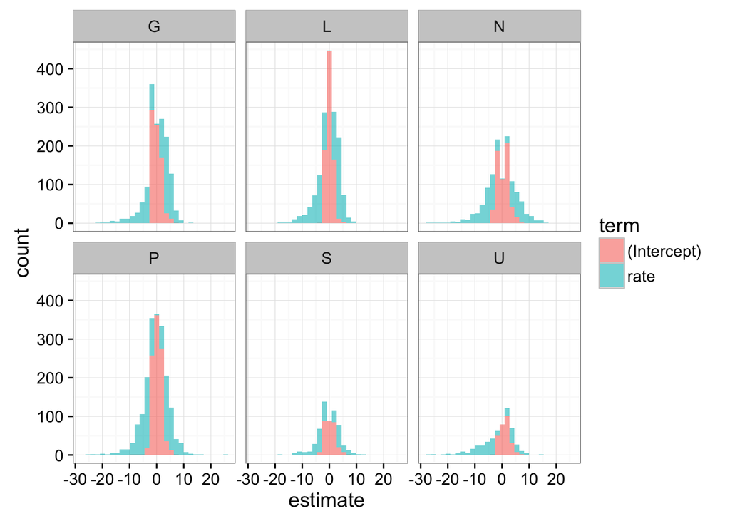

```r
cleaned_lm %>%
  filter(rsq > 0.9) %>%
  unnest(tidy) %>%
  ggplot(aes(x = estimate, fill = term))+
  geom_histogram(alpha = 0.6)+
  facet_wrap(~ nutrient)
```

## 3.4 Explore models

Now, we would like to find out how many of the ‘linear-trend’ genes are overlapping to the nutrient starvations.

- Starting from `cleaned_lm`, filter out the models with $r^2 < 0.9$ and empty the systematic names (*i.e* = “”).
- select only the `systematic_name` and `nutrient` columns
- add a column `set` containing `1` in all rows.
- convert from long to wide format (`nutrient` filled up by `set`). All absent genes will then be NAs.

## Solution

```r
cleaned_lm %>%
  filter(rsq > 0.9, systematic_name != "") %>%
  select(systematic_name, nutrient) %>%
  mutate(set = 1) %>%
  spread(nutrient, set) -> mat
```

- Move `the systematic` from the column to rownames (`tibble::column_to_rownames()`) Save as `mat_upset`
- The pseudo matrix is almost done: we get an absence as `NA` and a presence as `1`.
- Replace all `NA` by 0
- Set the class of `mat_upset` to `data.frame` as `upset` does not handle `tbl_df`.
- plot the upset using `upset(mat_upset)`

## Solution

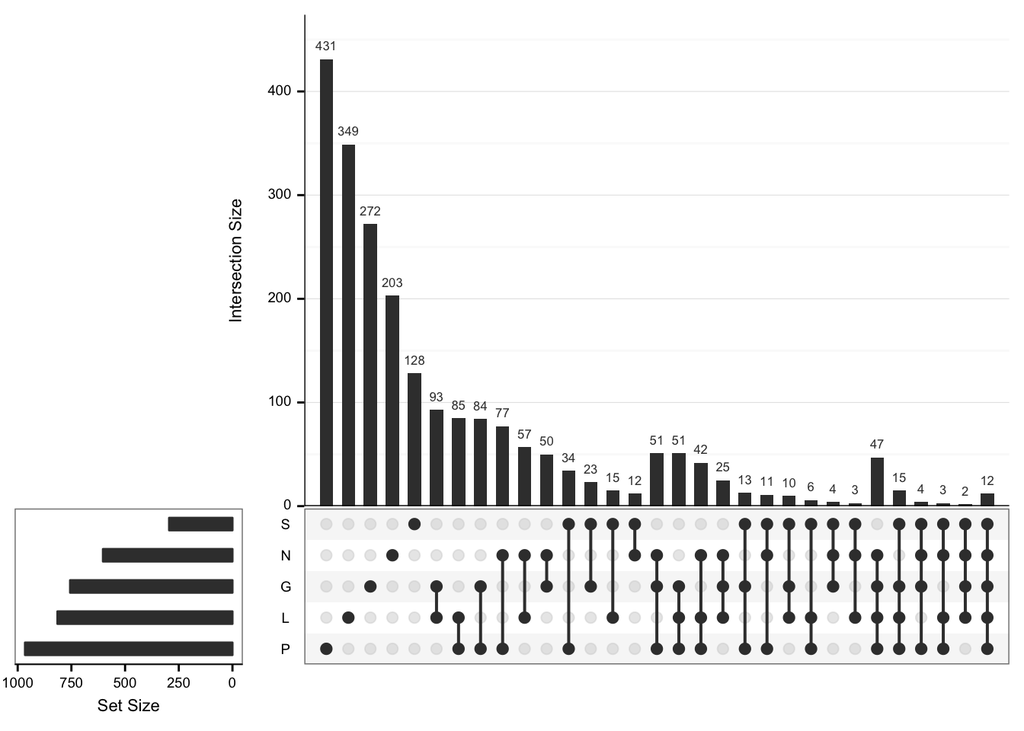

```r
library("UpSetR")
mat %>%
  tibble::column_to_rownames("systematic_name") -> mat_upset
mat_upset[is.na(mat_upset)]  <- 0
class(mat_upset) <- "data.frame"
upset(mat_upset)
```

[unilur Rmarkdown template](http://eric.koncina.eu/r/unilur/) - E. Koncina